# CadenaCritica 08

compromiso 46 frente a 52 días; Monte Carlo de 20000 réplicas

# Enunciado

Un proyecto se programa con el método de la cadena crítica. Para cada actividad, su responsable ha dado una estimación **segura** (con la que cumpliría aproximadamente nueve de cada diez veces, el percentil 90) y una estimación **agresiva pero alcanzable** (la mediana, el percentil 50), ambas en días. Las actividades no comparten recursos. Los colchones se dimensionan por cortar y pegar, redondeados al día superior.

1. Obtenga el plan de cadena crítica: cadena, colchón del proyecto, colchones de alimentación y fecha comprometida, y la duración del cronograma tradicional (estimaciones seguras).

2. Simule 20000 ejecuciones (semilla 6361) en las que las duraciones son independientes y lognormales, con mediana la estimación agresiva y percentil 90 la segura (σ del logaritmo = ln(segura/agresiva)/1,2816; constante si coinciden); las actividades de la cadena empiezan en cuanto terminan sus predecesoras y las de alimentación no antes de su inicio del plan. Calcule la probabilidad de terminar en la duración de la cadena, en la fecha comprometida y en la duración del cronograma tradicional.

3. ¿Qué colchón del proyecto haría falta para cumplir con probabilidad 0,90? ¿Y 0,95? Compare con los colchones de cortar y pegar y de la raíz de la suma de cuadrados.

4. Simule también la cadena crítica aislada (la suma de las duraciones de sus actividades). ¿Qué probabilidad tendría de cumplir la fecha comprometida? Explique la diferencia con el proyecto completo. ¿Estaba sobreprotegido el cronograma tradicional?

Tabla 1: Cuadro de datos del enunciado (días)

| activity | predecessor | agresiva | segura |
| --- | --- | --- | --- |
| A | --- | 7 | 10 |
| B | --- | 3 | 5 |
| C | --- | 9 | 11 |
| D | A | 9 | 11 |
| E | D | 7 | 11 |
| F | B,C,E | 3 | 4 |
| G | C,D | 9 | 12 |
| H | E,G | 7 | 9 |
| I | F,H | 8 | 10 |

El proyecto corresponde a la apertura de una clínica veterinaria; las actividades son las siguientes (las duraciones del cuadro están en días).

Tabla 2: Descripción de las actividades

|  | Descripción |
| --- | --- |
| A | Estudio de mercado y local |
| B | Proyecto de reforma y licencia |
| C | Obra de reforma |
| D | Instalación de quirófano y radiología |
| E | Mobiliario y equipamiento clínico |
| F | Software de gestión |
| G | Selección de personal |
| H | Acuerdos con proveedores |
| I | Registro sanitario |

# Resolución

## Apartado 1

1. Obtenga el plan de cadena crítica: cadena, colchón del proyecto, colchones de alimentación y fecha comprometida, y la duración del cronograma tradicional (estimaciones seguras).

[figure not shown]

Figura 1: Grafo PERT con las estimaciones agresivas y la cadena crítica

Cálculo de los tiempos tempranos y tardíos de los sucesos paso a paso (avance con los botones):

paso 0 de 33

[figure not shown]

|  | de | a | motivo | recurso |
| --- | --- | --- | --- | --- |
| 1 | A | D | precedencia |  |
| 2 | D | G | precedencia |  |
| 3 | G | H | precedencia |  |
| 4 | H | I | precedencia |  |

Tabla 3: Colchón del proyecto

|  | colchón del proyecto |
| --- | --- |
| cortar y pegar = 0,5·Σ márgenes | 0,5·(3 + 2 + 3 + 2 + 2) = 0,5·12 = 6 → 6 |
| raíz = √(Σ márgenes²) | √(3² + 2² + 3² + 2² + 2²) = √30 = 5.48 → 6 |

Tabla 4: Colchones de alimentación

|  | arco | cadena de alimentación | colchón requerido | holgura disponible = inicio de la cadena − fin más temprano | colchón adoptado = mín(requerido, disponible) |
| --- | --- | --- | --- | --- | --- |
| CA1 | C → G | C | 0,5·(2) = 1 → 1 | 16 − 9 = 7 | 1 |
| CA2 | E → H | E | 0,5·(4) = 2 → 2 | 25 − 23 = 2 | 2 |
| CA3 | F → I | C - F | 0,5·(2 + 1) = 1.5 → 2 | 32 − 26 = 6 | 2 |

[figure not shown]

Figura 2: Gantt del plan de cadena crítica

Cadena A - D - G - H - I de 40 días; colchón del proyecto 6; compromiso **46 días**. Cronograma tradicional (estimaciones seguras): **52 días**.

## Apartado 2

2. Simule 20000 ejecuciones (semilla 6361) en las que las duraciones son independientes y lognormales, con mediana la estimación agresiva y percentil 90 la segura (σ del logaritmo = ln(segura/agresiva)/1,2816; constante si coinciden); las actividades de la cadena empiezan en cuanto terminan sus predecesoras y las de alimentación no antes de su inicio del plan. Calcule la probabilidad de terminar en la duración de la cadena, en la fecha comprometida y en la duración del cronograma tradicional.

En cada réplica la duración de cada actividad es $a\,e^{\sigma Z}$, con $a$ la estimación agresiva, $Z$ normal tipificada y $\sigma = \ln(s/a)/1{,}2816$, de modo que su mediana es $a$ y su percentil 90 es $s$, la estimación segura. Con ellas se recorre la red (nivelada) hacia delante.

|  | duración de la cadena | fecha comprometida | cronograma tradicional |
| --- | --- | --- | --- |
| días | 40 | 46 | 52 |
| P(duración ≤ días) | 0.2402 | 0.8512 | 0.9898 |

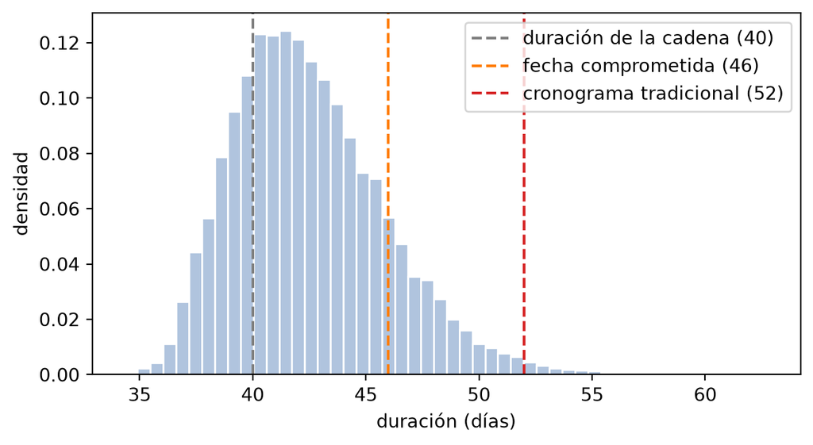

Figura 3: Distribución simulada de la duración del proyecto

## Apartado 3

3. ¿Qué colchón del proyecto haría falta para cumplir con probabilidad 0,90? ¿Y 0,95? Compare con los colchones de cortar y pegar y de la raíz de la suma de cuadrados.

Tabla 5: Colchón necesario para cada nivel de confianza

|  | P50 | P80 | P90 | P95 |
| --- | --- | --- | --- | --- |
| duración | 42.11 | 45.22 | 47.03 | 48.6 |
| colchón = ⌈percentil − T⌉ | ⌈42.11 − 40⌉ = 3 | ⌈45.22 − 40⌉ = 6 | ⌈47.03 − 40⌉ = 8 | ⌈48.60 − 40⌉ = 9 |

Para el 90 % harían falta 8 días de colchón y para el 95 %, 9. Cortar y pegar da 6 (probabilidad 0.851) y la raíz de la suma de cuadrados 6 (probabilidad 0.851).

## Apartado 4

4. Simule también la cadena crítica aislada (la suma de las duraciones de sus actividades). ¿Qué probabilidad tendría de cumplir la fecha comprometida? Explique la diferencia con el proyecto completo. ¿Estaba sobreprotegido el cronograma tradicional?

|  | cadena aislada | proyecto completo |
| --- | --- | --- |
| mediana | 40.752 | 42.106 |
| P(≤ fecha comprometida) | 0.902 | 0.851 |

La cadena aislada cumpliría la fecha comprometida con probabilidad 0.902; el proyecto completo, con 0.851. La diferencia es el **sesgo de convergencia**: en los puntos donde una cadena de alimentación desemboca en la cadena crítica manda la que llega más tarde, y a veces el retraso de la alimentación supera su colchón y pasa a la cadena. Los colchones de alimentación existen para que esa diferencia sea pequeña. El cronograma tradicional (52 días) se cumpliría con probabilidad 0.990 si se ejecutara por relevos: sus 6 días de más sobre el compromiso suben la probabilidad de 0.851 a 0.990: está sobreprotegido, y además, por la ley de Parkinson, esos días tenderían a consumirse igualmente.

## Autoevaluación

Preguntas de respuesta múltiple con los datos de este ejercicio (la correcta, marcada con ✅, es la primera de cada lista). La celda las exporta también en formato GIFT, con las opciones barajadas, a `~/temp/cuestionario_cadena_critica.gift`, para importarlas en Moodle.

**1. Según la simulación, ¿con qué probabilidad se cumple la fecha comprometida?**

- ✅ 0,85

- ◻️ 0,24

- ◻️ 0,99

- ◻️ 0,90

*Proporción de réplicas que terminan en 46 días o menos: 0,851.*

**2. ¿Qué colchón del proyecto haría falta para cumplir con probabilidad 0,90?**

- ✅ 8 días

- ◻️ 6 días

- ◻️ 9 días

- ◻️ 3 días

*Percentil 90 de la duración simulada menos la duración de la cadena (40), redondeado al día superior: 8.*

**3. ¿Por qué el proyecto completo cumple la fecha con menos probabilidad que la cadena crítica aislada?**

- ✅ por el sesgo de convergencia: en las uniones manda el camino que llega más tarde

- ◻️ porque el colchón de cortar y pegar está mal calculado

- ◻️ porque la simulación usa duraciones lognormales

- ◻️ porque las actividades de alimentación empiezan antes de lo previsto

*Los colchones de alimentación existen para que esa diferencia sea pequeña.*